# Latimer_phenology_notebook

Data collected by John Latimer data annotated by Claudia Nanninga code written by David J. Weston & Travis Lawrence

01/30/2019

# 1 Introduction

The goal of this R notebook tutorial is to introduce the public to the importance of community science along with its inherent limitations.

# 2 2018 Data import and initials glimpse

The original data provided by Latimer is in typical date format. However, ecologists and climate scientist often use Julian day format to provide a continuous count of the days starting at January 1st each year. Each year will contain 365 days or 366 days if a leap years

Code for changing the date format to the Julian day format was modified from the Neon site: https://www.neonscience.org/Julian-day-conversion-r

```
##         date        event common_name    genus species county lifeform
## 1 1990-03-20    FLOWERING       ALDER    ALNUS      SP ITASCA   PLANTS
## 2 1987-02-27    FLOWERING       ALDER    ALNUS      SP ITASCA   PLANTS
## 3 1986-03-02    FLOWERING       ALDER    ALNUS      SP ITASCA   PLANTS
## 4 2016-06-17    FLOWERING     ALFALFA MEDICAGO  SATIVA ITASCA   PLANTS
## 5 2015-09-05 LAST FLOWERS     ALFALFA MEDICAGO  SATIVA ITASCA   PLANTS
## 6 2013-07-02    FLOWERING     ALFALFA MEDICAGO  SATIVA ITASCA   PLANTS
##   group dataset_num invasive
## 1 WOODY           1
## 2 WOODY           1
## 3 WOODY           1
## 4  FORB           1
## 5  FORB           1
## 6  FORB           1
```

The data are impressive! Over a 32 year span, Latimer manually collected 10,484 phenology observations. Along with the date recorded, Latimer and Nanninga added 9 other variable (e.g., genus, species, common name, lifeform, etc.) for a total of 104,840 total observations. This is just the start, our dataset stops at 2016 while latimer continues to record phenology observations.

```
## # A tibble: 33 x 3
##    year  `max(julian)` `min(julian)`
##    <chr>         <dbl>         <dbl>
##  1 1984            365            60
##  2 1985            310            34
##  3 1986            343            11
##  4 1987            362             9
##  5 1988            333             2
##  6 1989            305             4
##  7 1990            321             2
##  8 1991            338            17
##  9 1992            363            26
## 10 1993            308            32
## # ... with 23 more rows
```

We can see from the above partial table that Latimer did not record observations daily. This makes sense as plants are dormant in the winter and birds seasonally migrate.

As a quick check on the Julian day conversion, I looked at 06-27 Julian days. on regular years it is 178, on leap years (2000,2004,2008,2012, etc) it is 179. That was confirmed for this one date.

Now lets get a feel for the data, especially in regard to plants.

```
## # A tibble: 392 x 2
##    common_name                     n
##    <fct>                       <int>
##  1 PUSSY WILLOW                   70
##  2 TREMBLING ASPEN                39
##  3 STARFLOWER                     36
##  4 SPECKLED ALDER [HOARY A]       35
##  5 DANDELION                      33
##  6 COMMON LILAC                   31
##  7 COMMON MILKWEED                31
##  8 FIREWEED                       31
##  9 BIG TOOTHED ASPEN              30
## 10 PIN CHERRY [FIRE C, BIRD C]    30
## # ... with 382 more rows
```

From the above table, we see that there are 392 plants that were observed over the years. However, many have a sparse number of observations that are difficult to build models for.

Here is a look at the data distribution

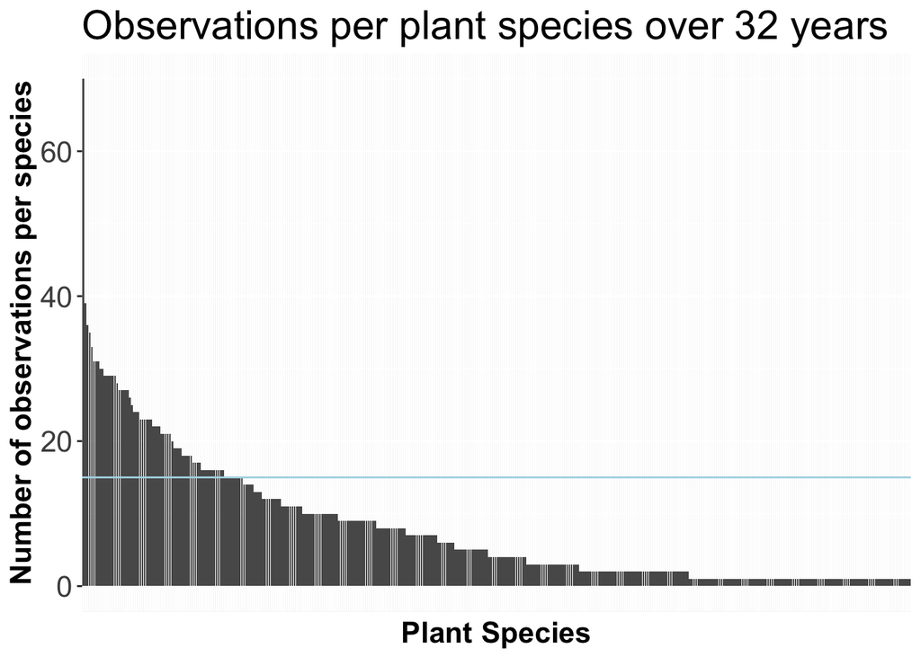

Fig. 1: Bar plot for the number of observations Latimer made on plants regarding flowering time. Each bar represents one species, and the number of observations (y-axis) is cumulative over the 32 years of community science data collection. Latimer recorded an impressive 392 plant species for flowering related traits. The blue horizontal line represents the cutoff for 76 species that have 15 or more observations that we will use for furhter analyses.

We can see from the histogram that the majority of data are sparse indeed, with less than 10 observations.

Now that the data are tidy (in a format to easily compute on), lets run a linear model across all 76 species through the 32 years of data. Further, lets extract the model slope and P - value to identify candidate species for further investigation on flowing time correlations with time of year.

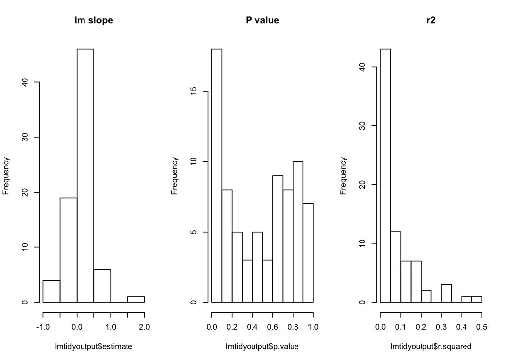

Fig. 2: Basic frequency plots for linear model paramters across the 76 plant species investigated (those with a minimum of 15 years of observations

The above histograms show distributions of linear model parameters.

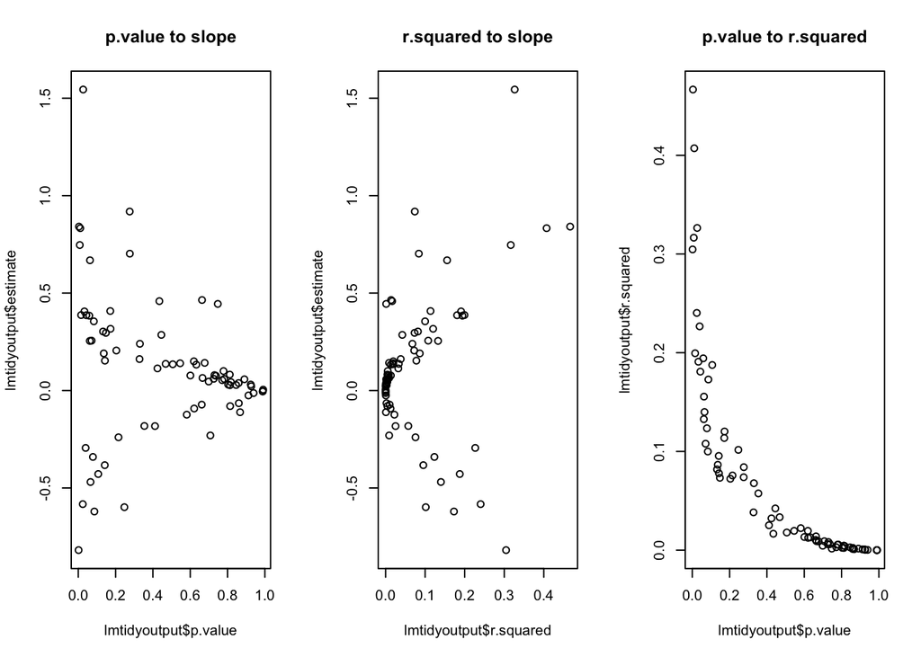

Fig. 3: Relationship among linear regression parameters

The above scatter plots show the relationships for linear model parameters to each other.

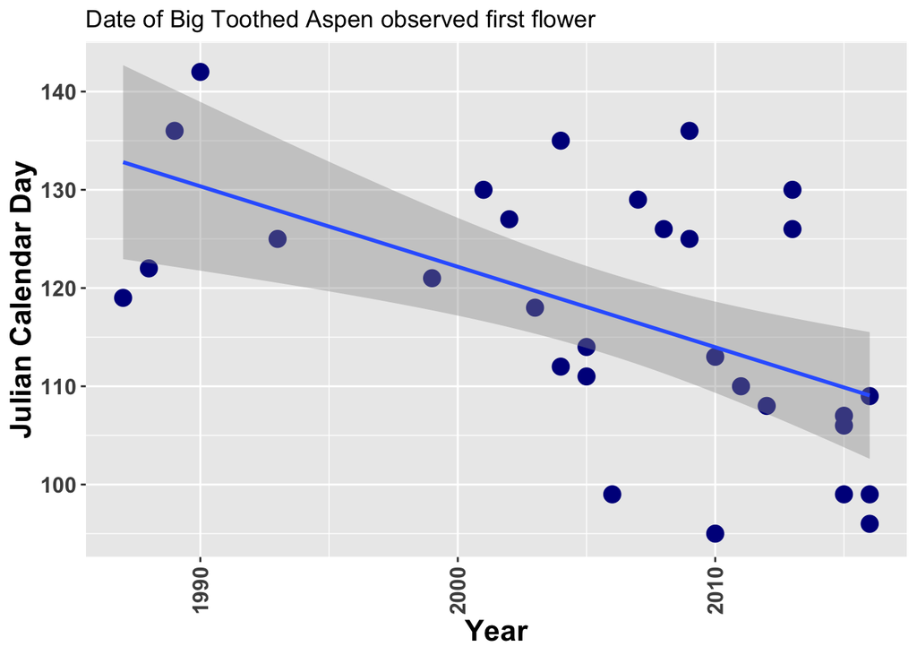

Fig. 4: Scatter plot of Julian day in which Big Toothed Aspen was observed to first flower across year. The linear regression prediction line is in blue, while the 95% confidence interval is depicted in gray shading.

Notice that there are not many observations between 1990 and 2000. To add confidence to the regression trend lets restrict the analysis to those years above 2000.

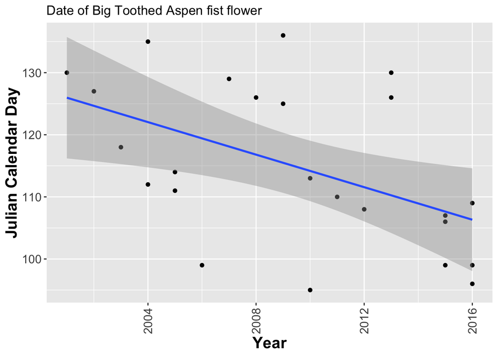

Fig. 5: Scatter plot of Julian day in which Big Toothed Aspen was observed to first flower across year. Similar to Fig. 4 but wil fewer years of observations. The linear regression prediction line is in blue, while the 95% confidence interval is depicted in gray shading.

The trend between the Fig. 4 & 5 is similar, suggesting that Big Toothed Aspen is progressively flowering earlier in the season.

Now lets look at trends across other plants, do they all show the same trend?

```
## [1] 1587   13
```

```
## # A tibble: 6 x 13
##   common_name date       event genus species county lifeform group
##   <fct>       <date>     <fct> <fct> <fct>   <fct>  <fct>    <fct>
## 1 PUSSY WILL… 2016-04-14 FLOW… SALIX DISCOL… ITASCA PLANTS   WOODY
## 2 PUSSY WILL… 2016-02-24 FLOW… SALIX DISCOL… ITASCA PLANTS   WOODY
## 3 PUSSY WILL… 2015-04-11 FLOW… SALIX DISCOL… ITASCA PLANTS   WOODY
## 4 PUSSY WILL… 2015-03-11 FLOW… SALIX DISCOL… ITASCA PLANTS   WOODY
## 5 PUSSY WILL… 2015-03-11 FLOW… SALIX DISCOL… ITASCA PLANTS   WOODY
## 6 PUSSY WILL… 2014-11-23 FLOW… SALIX DISCOL… ITASCA PLANTS   WOODY
## # ... with 5 more variables: dataset_num <int>, invasive <fct>,
## #   month <chr>, year <dbl>, julian <dbl>
```

Now lets write code for a model that looks for regression trends among flowering day and year for all plant species meeting a 15 year minimum criterion.

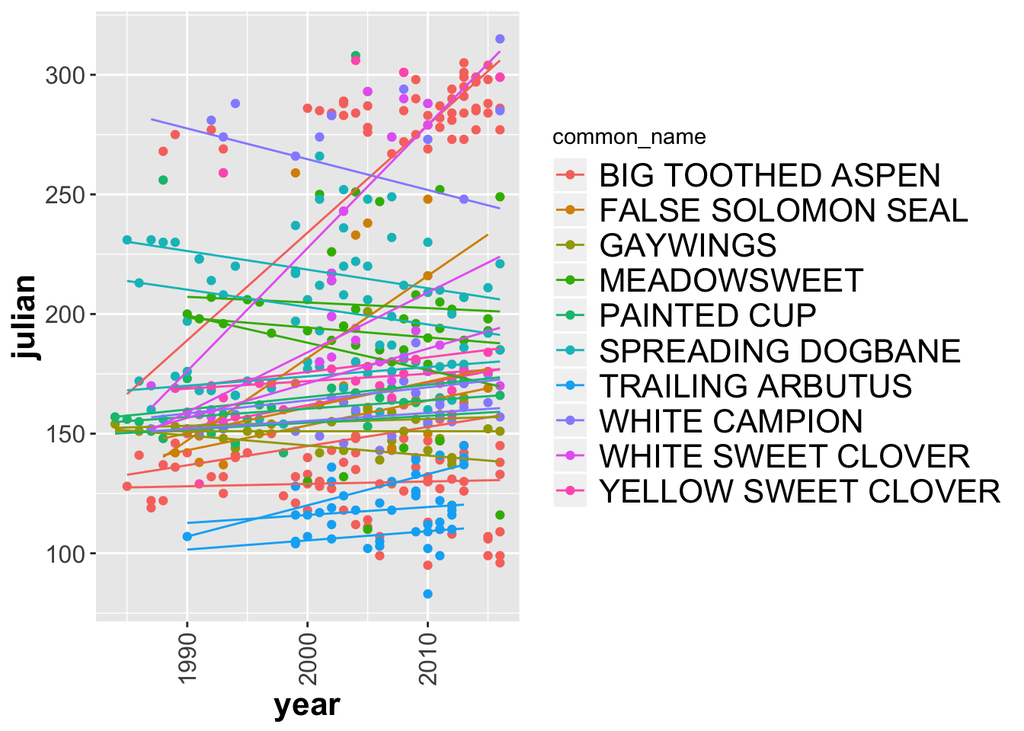

Figure 6 shows numerous trends in the data. Below we plot these species individually through a multiple graphing function

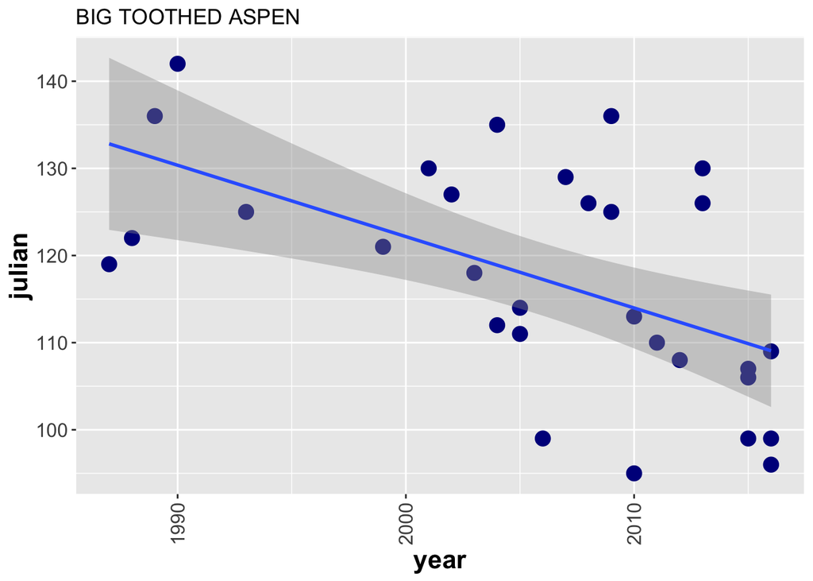

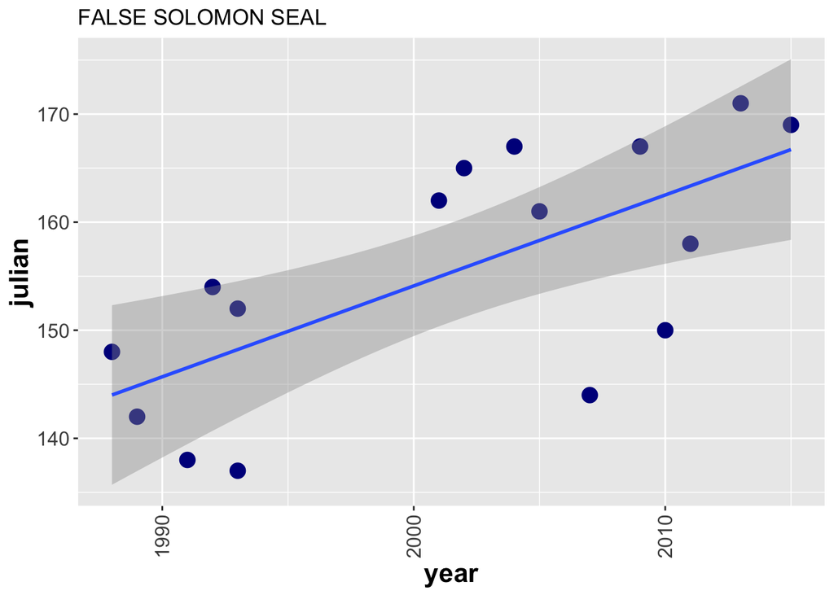

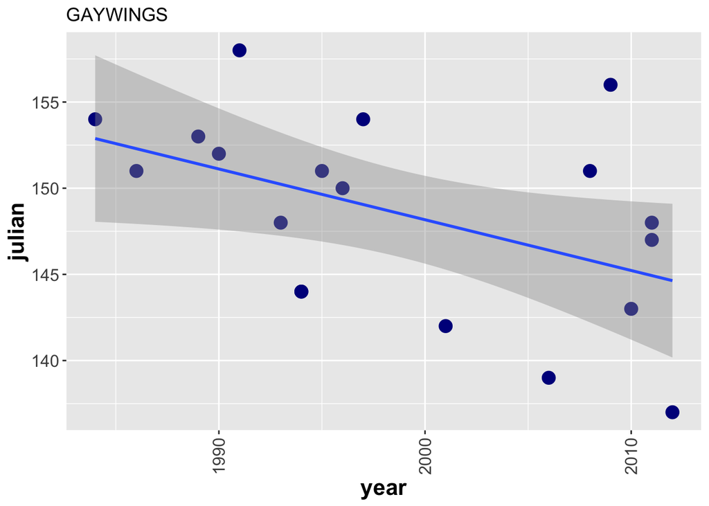

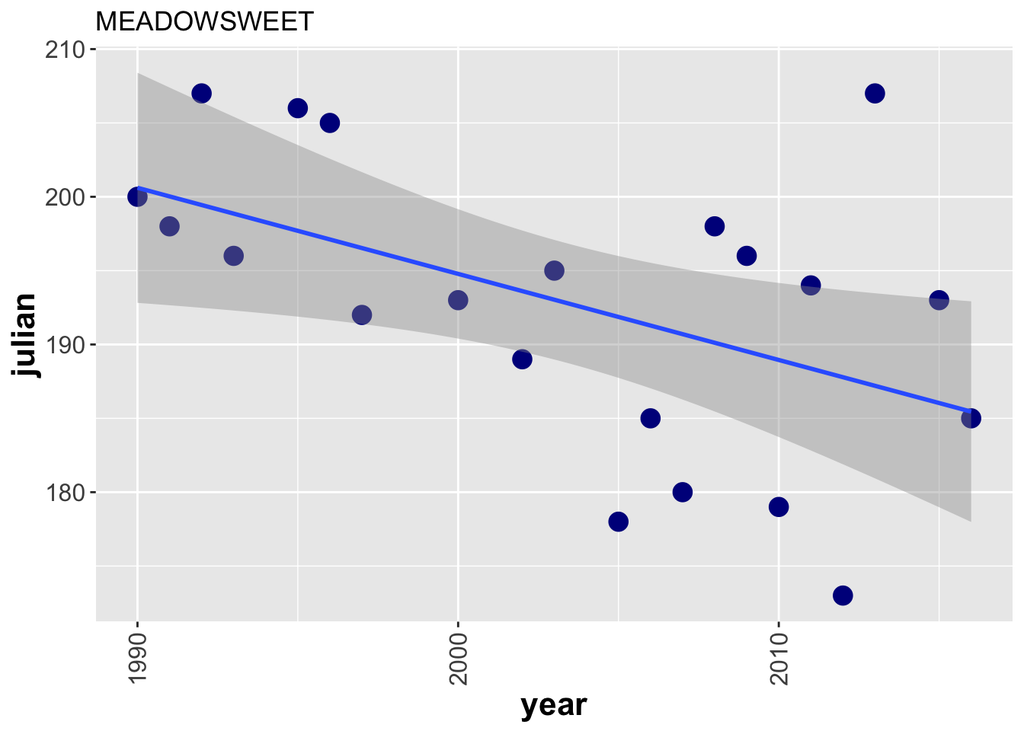

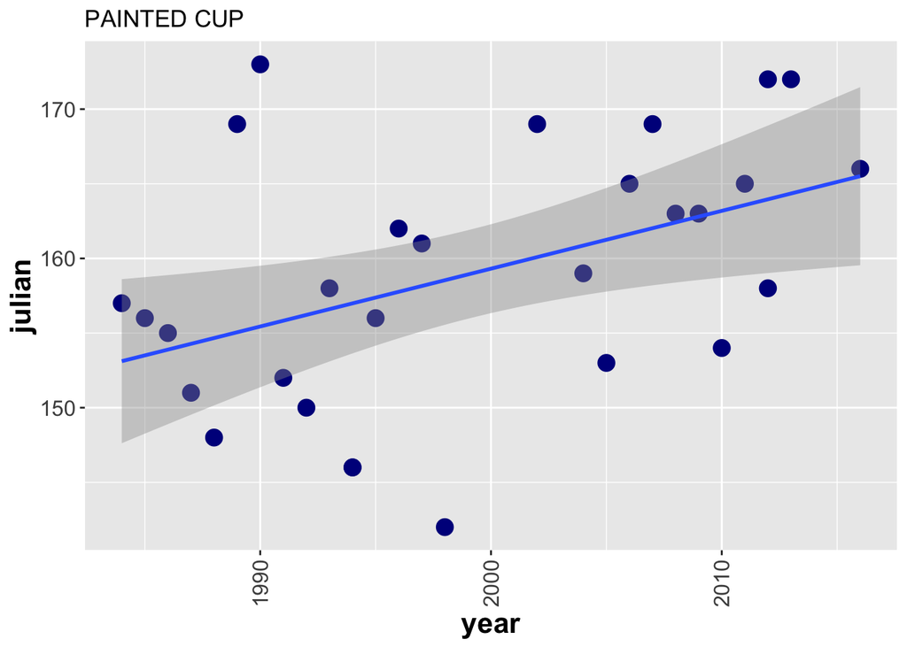

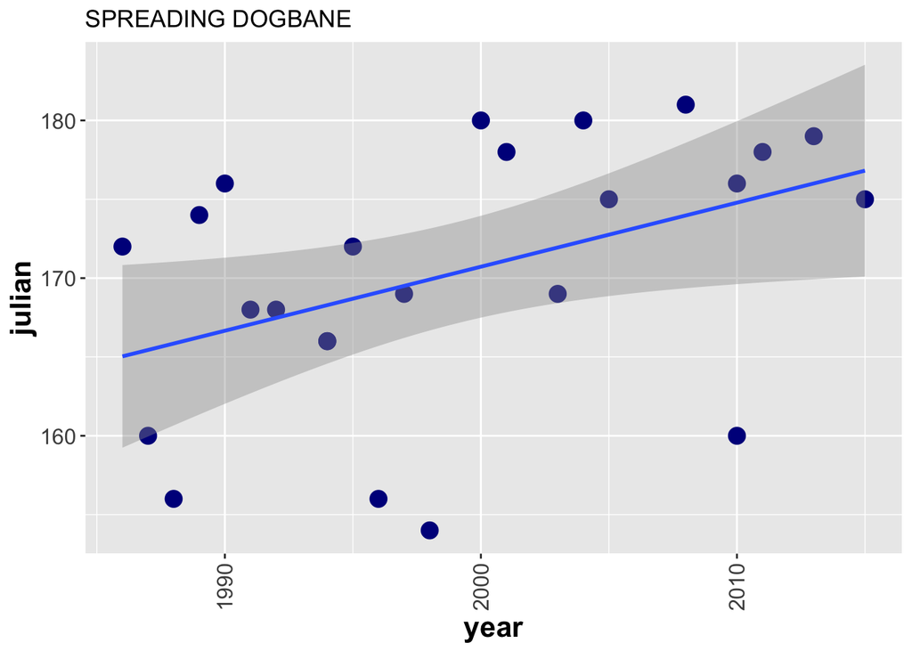

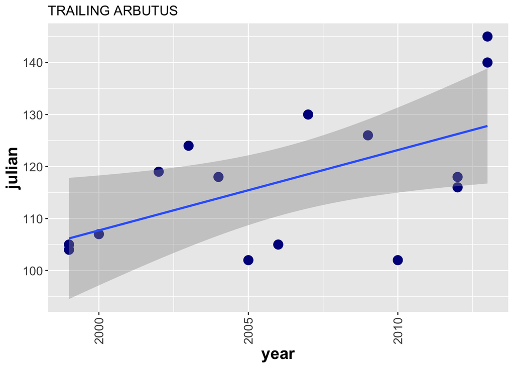

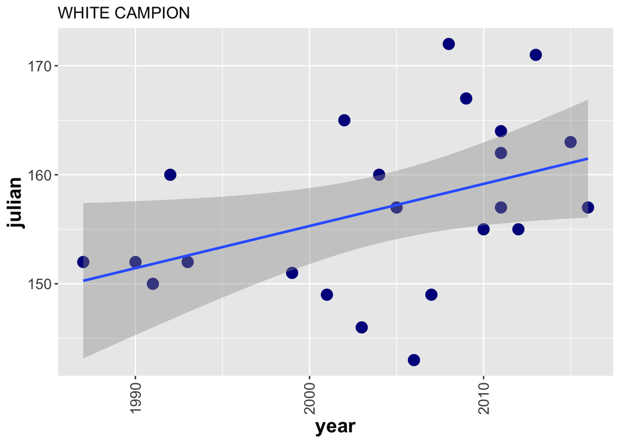

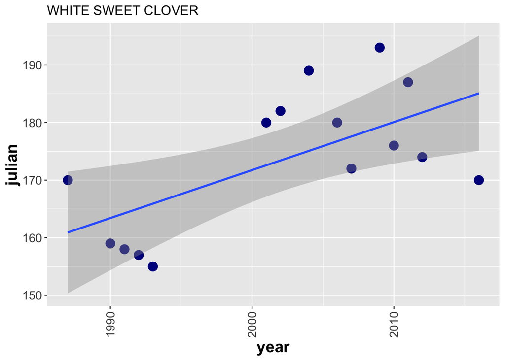

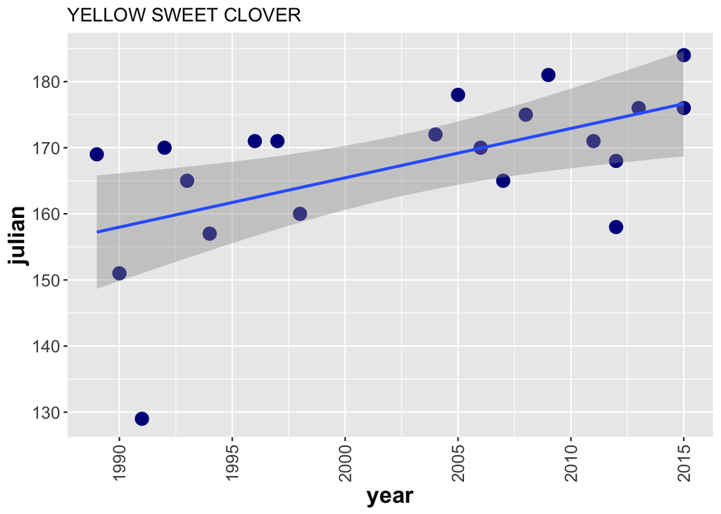

The graphs show some interesting trends, some species seem to flower earlier in the year - like Big Toothed Aspen, while others may be flowering later in the year. See False Solomon’s Seal as an example. To really have confidence in these trends, one would need to determine that linear model assumptions are met.

Using the above code one can explore the Latimer bird data in a similar way. If you do so, you will notice that the bird data is much more sparse than the plant data. Suggesting that Latimer was more interested in observing plant phenology than bird phenology. Below is an example graph chosen because of numerous observations (abundant data) that exhibit a seemingly non-responsive trend. An informed public must keep in mind that graphs showing exaggerated trends may not be the norm, indeed the Dark Eyed Junco seems to be non-responsive to year observed - see below

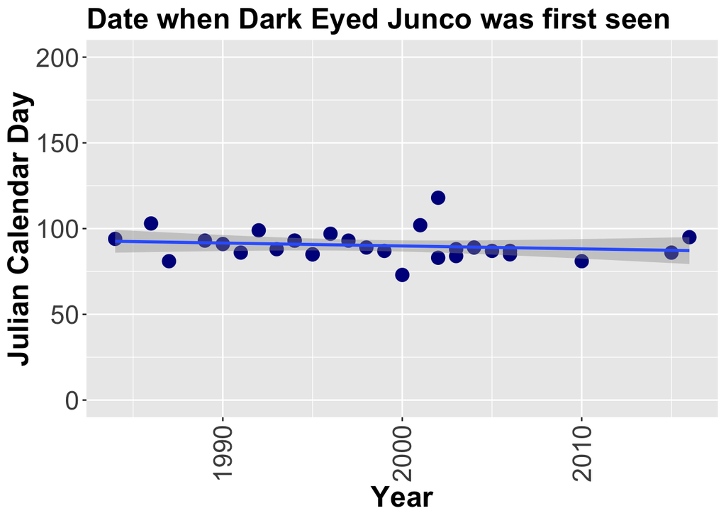

Fig. 7: Example plot for bird data showing the Julian day on which the Dark Eyed Junco was first seen over 32 years. The plot suggests that this bird speices is very consistant with spring migration timing.